# Question

Consider the curve represented by the equation below:

$$y~=~\frac{1}{x+6}-3$$

Does the curve $y=\frac{1}{x+6}-3$ have a horizontal [asymptote](https://en.wikipedia.org/wiki/Asymptote)?

##ANSWER1##

Does the curve $y=\frac{1}{x+6}-3$ have a vertical [asymptote](https://en.wikipedia.org/wiki/Asymptote)?

##ANSWER2##

## Answerlist

- Yes, at x=-6.
- Yes, at x=-3.
- Yes, at x=3.
- Yes, at x=6.
- Yes, at y=-6.
- Yes, at y=-3.
- Yes, at y=3.
- Yes, at y=6.
- No.
- Yes, at x=-6.
- Yes, at x=-3.
- Yes, at x=3.
- Yes, at x=6.
- Yes, at y=-6.
- Yes, at y=-3.
- Yes, at y=3.
- Yes, at y=6.
- No.

# Solution

The horizontal and vertical asymptotes are shown below as a red dashed lines. The blue curve represents $y=\frac{1}{x+6}-3$.

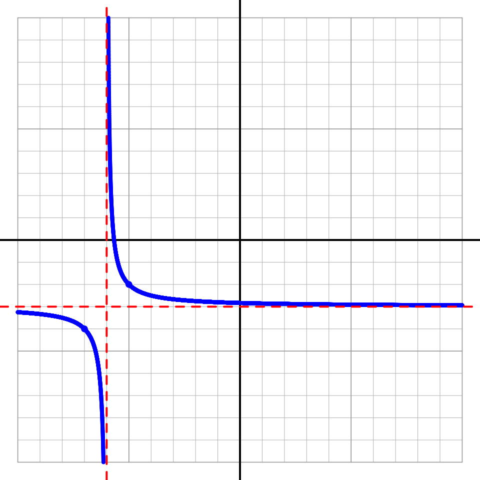

Notice, the parent function, $y=\frac{1}{x}$, has a horizontal asymptote at $y=0$ and a vertical asymptote at $x=0$. When we shift the points up or down, the horizontal asymptote also shifts up or down. When we shift the points left or right, the vertical asymptote also shifts left or right.

# Meta-information

extype: cloze exclozetype: schoice|schoice exsolution: 000001000|100000000 exname: asymp_recip